# Linear Regression #1

Ramadharsh Vanchinathan

# Simple Linear Regression

Single regressor,$x$; response,$y$

$$y = \beta_0 + \beta_1x + \epsilon$$

- $\beta_0$ - intercept if x = 0 is in the range, then β0 is the mean of the distribution of the response y, when x = 0; if x = 0 is not in the range, then $\beta_0$ has no practical interpretation
- $\beta_1$ – slope: change in the mean of the distribution of the response produced by a unit change in x
- $\epsilon$ - random error

Mean: $E(y|x) = \beta_0 + \beta_1x$

Variance: $Var(y|x) = Var(\beta_0 + \beta_1x + \epsilon) = \sigma^2$

$\beta_0$ and $\beta_1$ are unknown and must be estimated

$y_i = \beta_0 + \beta_1x_i + \epsilon_i,i=1,2,...,n$

Least Squares estimation:

Minimize $S(\beta_0,\beta_1) = \sum_i\epsilon^2_i = \sum_i(y_i - \beta_0 - \beta_1x_i)^2$

## Estimating Fitted Least Squares Regression Line

**Calculate $S_{xx}$ and $S_{xy}$.**

$S_{xx} = \sum_i^n x^2_i - \frac{(\sum_i^nx_i)^2}{n}$

$S_{xy} = \sum_i^n x_iy_i - \frac{\sum_i^n x_i \sum_i^n y_i}{n}$

**Calculate $\hat \beta_1$ using $S_{xx}$ and $S_{xy}$.**

$\hat \beta_1 = \frac{S_{xy}}{S_{xx}}$

**Calculate $\hat \beta_0$ using $\hat \beta_1$.**

$\hat \beta_0 = \overline y - \hat \beta_1 \overline x$

**Define $\hat y$.**

$\hat y = \hat \beta_0 + \hat \beta_1x$

## Real World Implementation

X: age of propellant y: shear strength of propellant

Using Linear Regression, we can estimate how much shear strength the propellant will have within a reasonable amount.

```r
dat=read.csv("data/rocketpropellant.csv", header = T)
head(dat)
```

|  | y | x |
| --- | --- | --- |
| 1 | 2158.70 | 15.50 |
| 2 | 1678.15 | 23.75 |
| 3 | 2316.00 | 8.00 |
| 4 | 2061.30 | 17.00 |
| 5 | 2207.50 | 5.50 |
| 6 | 1708.30 | 19.00 |

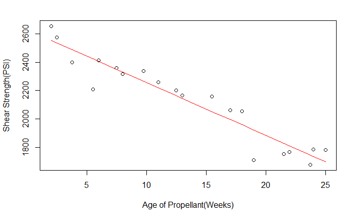

```r
x=dat[,2]
y=dat[,1]
n=length(x)

# Sums of Squares
Sxx=sum(x^2)-sum(x)^2/n
Sxy=sum(x*y)-sum(x)*sum(y)/n

#LS estimates
B1H=Sxy/ Sxx
B0H=mean(y)-mean(x)*B1H

#estimated/fitted SLR line
yH=B0H + sort(x)*B1H

#plotting
plot(x,y, ylab = "Shear Strength(PSI)", xlab = "Age of Propellant(Weeks)")
lines(sort(x),yH, col="red")
```